# 11. Emissões radiadas e suscetibilidade

## 11.7 Ensaios radiados

Em emissão, distância, polarização, altura, azimute, detector e ambiente são controlados. Em imunidade, busca-se uma região de campo uniforme e monitora-se o critério funcional durante a varredura. Cabos devem ocupar a configuração prescrita, pois são parte da antena.

Resultados perto do limite devem incluir incerteza e variabilidade. Uma alteração que melhora uma orientação pode piorar outra; por isso a validação deve cobrir toda a banda e configuração de pior caso.

## 11.8 Diagnóstico pelo efeito dominante

1. Correlacionar picos com fontes internas.
2. Medir corrente de modo comum nos cabos.
3. Fazer varredura de campo próximo sobre PCB e interfaces.
4. Alterar temporariamente área de laço, terminação de blindagem ou ferrite.
5. Observar qual intervenção muda significativamente o resultado.
6. Implementar a solução na fonte e repetir o ensaio completo.

## 11.9 Teoremas e derivações

**Proposição**: Para um pequeno laço, reduzir todas as dimensões lineares por um fator $k$, mantendo corrente e frequência, reduz o campo distante por $k^2$.

**Prova**: O campo do pequeno laço é proporcional à área $A$. Se cada dimensão é multiplicada por $k$, então $A'=k^2A$ e, portanto, $E'=k^2E$. $\square$

**Proposição**: Um par perfeitamente balanceado, observado a distância muito maior que sua separação, cancela a primeira contribuição de dipolo elétrico associada às correntes diferenciais.

**Prova**: Os campos produzidos por correntes iguais e opostas têm praticamente a mesma amplitude e fase no observador distante. Sua soma de primeira ordem se anula; resta a contribuição ligada à separação finita, equivalente ao pequeno laço. Assimetrias e modo comum destroem o cancelamento. $\square$

## 11.10 Exemplo resolvido — Comparação de mitigação

Um laço retangular de 40 mm por 20 mm é reduzido para 20 mm por 10 mm. A área passa de 800 para 200 mm². Pelo modelo de pequeno laço,

$$ \frac{E_2}{E_1}=\frac{A_2}{A_1}=0{,}25, $$

uma redução ideal de

$$ 20\log_{10}(0{,}25)=-12{,}0\ \text{dB}. $$

A estimativa vale se corrente, frequência, distância e regime de pequeno laço permanecerem iguais.

## 11.11 Exemplo resolvido — Corrente de modo comum

Uma sonda possui impedância de transferência $Z_T=1\ \Omega$ na frequência do pico. O receptor mede 54 dBµV:

$$ V=10^{54/20}\ \mu\text{V}=501\ \mu\text{V}, $$

$$ I_{CM}=\frac{V}{Z_T}=501\ \mu\text{A}. $$

Se uma mitigação reduz a leitura para 40 dBµV, a corrente cai para 100 µA, melhoria de 14 dB.

## 11.12 Insight: conversão de modo é frequentemente o elo oculto

Um driver diferencial pode ser eletricamente silencioso no modelo ideal e ainda excitar cabo em modo comum. Diferença de capacitância para chassi, skew, impedâncias desiguais e pinagem assimétrica convertem parte do sinal. Por isso, medir apenas a corrente diferencial ou apenas o espectro do driver pode não revelar o mecanismo radiador.

## 11.13 Lista de Exercícios Propostos

**E.1** Compare a dependência em frequência dos modelos curtos de emissão diferencial e comum.

**E.2** Explique como uma fenda no plano de retorno aumenta emissão.

**E.3** Descreva como medir corrente de modo comum com uma sonda clamp.

**E.4** Por que uma corrente de modo comum pequena pode dominar uma corrente diferencial maior?

**E.5** Explique por que a conexão do conector à blindagem pode dominar o desempenho de um cabo blindado.

**E.6** Um laço tem área reduzida de 12 para 3 cm². Estime a redução de campo em dB.

**E.7** Uma sonda com $Z_T=0{,}5\ \Omega$ produz 200 µV no receptor. Qual é a corrente no cabo?

**E.8** Cite três assimetrias que convertem modo diferencial em modo comum.

## 11.14 Gabarito

**E.6** Redução de campo em dB para laço com área reduzida de 12 para 3 cm².

Razão de áreas: $A_2/A_1=3/12=0{,}25$.

A emissão de campo para um pequeno laço é proporcional à área: $E\propto A$.

Redução em dB: $10\log_{10}(0{,}25)=10\cdot(-0{,}602)=-6{,}02$ dB para potência, ou $20\log_{10}(0{,}25)=-12{,}04$ dB para campo.

Resposta: Razão 0,25, portanto $-12{,}0$ dB.

**E.7** Corrente no cabo com sonda de $Z_T=0{,}5\ \Omega$ produzindo 200 µV.

Equação: $I=V/Z_T$.

$I=200\ \mu\text{V}/0{,}5\ \Omega=400\ \mu\text{A}$.

Resposta: $I=400\ \mu\text{A}$.

**E.8** Três assimetrias que convertem modo diferencial em modo comum.

1. Capacitâncias desiguais para chassi entre os condutores de ida e volta.
2. Impedâncias de saída diferentes nos drivers de ida e volta.
3. Pinagem/conector assimétrico, skew (diferenças de tempo de propagação) ou terminação desbalanceada.

Outros exemplos: diferenças de geometria de trilhas, desbalanceamento de componentes parasitas.

## 11.15 Exemplo numérico adicional — Emissão diferencial vs. comum

Laço diferencial: $A=20\times10\ \text{mm}^2=2\times10^{-4}\ \text{m}^2$, $I_{DM}=100$ mA, $f=50$ MHz.  
Campo diferencial: $E_{DM}\propto f^2 I_{DM} A/r$.

Cabo comum: $l=0.5$ m, $I_{CM}=10$ mA, $f=50$ MHz.  
Campo comum: $E_{CM}\propto f I_{CM} l/r$.

## 11.16 Código Python — Comparação de emissão diferencial e comum vs. frequência

PYTHON

```
import numpy as np
import matplotlib.pyplot as plt

f = np.logspace(6, 9, 100)  # 1 MHz a 1 GHz

# Parâmetros
I_DM = 0.1      # 100 mA
A = 2e-4        # 20x10 mm^2 em m^2
I_CM = 0.01     # 10 mA
l = 0.5         # 0.5 m

# Campos proporcionais
E_DM_prop = (f**2) * I_DM * A
E_CM_prop = f * I_CM * l

plt.figure(figsize=(8, 5))
plt.semilogx(f, E_DM_prop, 'b-', linewidth=2, label='E_DM proporcional')
plt.semilogx(f, E_CM_prop, 'r-', linewidth=2, label='E_CM proporcional')
plt.xlabel('Frequência (Hz)')
plt.ylabel('Campo Proporcional')
plt.title('Emissão Diferencial vs Comum vs Frequência')
plt.legend()
plt.grid(True, which='both', linestyle='--')
plt.show()
```

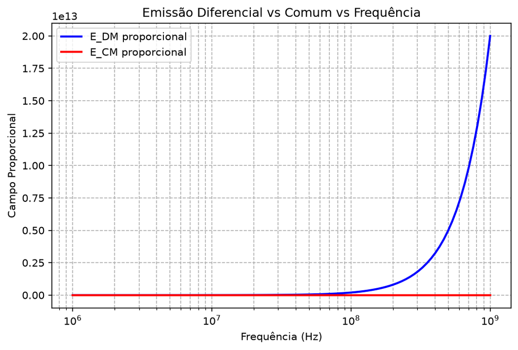

## 11.17 Exemplo numérico adicional — Conversão de dB para campo elétrico

**Problema**: Um receptor mede 54 dBµV com uma antena de fator 18 dB/m. Qual é o campo elétrico?

**Solução**:

Tensão medida: $V=10^{54/20}$ µV = $501$ µV = $0.501$ mV.

Em dBµV/m: $E_{dB\mu V/m}=V_{dB\mu V}+AF_{dB/m}=54+18=72$ dBµV/m.

> **Insight para Estudantes**: O fator de antena converte tensão medida no receptor para campo elétrico incidente. Ele depende da frequência, do tipo de antena, e da calibração. Sempre verifique se o fator de antena inclui perdas de cabo e ganhos de pré-amplificador.

## 11.18 Orçamento de emissão: da corrente ao campo

Para um pequeno loop diferencial de área $A$ e corrente senoidal RMS $I_{DM}$, uma estimativa de campo distante máximo é

$$ E_{DM}\approx\frac{\eta_0\beta^2 I_{DM}A}{4\pi r}. $$

Para um condutor curto de comprimento efetivo $l_{eff}$ com corrente CM,

$$ E_{CM}\approx\frac{\eta_0\beta I_{CM}l_{eff}}{4\pi r}. $$

Logo,

$$ \frac{E_{CM}}{E_{DM}}\approx \frac{I_{CM}}{I_{DM}}\frac{l_{eff}}{\beta A}. $$

**Corolário.** Como $\beta A$ pode ser muito menor que o comprimento efetivo do cabo, uma corrente CM dezenas ou centenas de vezes menor pode dominar a emissão.

## 11.19 Código Python — orçamento DM/CM e limite

PYTHON

```
import numpy as np
import matplotlib.pyplot as plt

eta0, c, r = 376.730313, 299_792_458.0, 3.0
f = np.logspace(6, 9, 600)
beta = 2*np.pi*f/c
Idm, Icm = 20e-3, 50e-6
A, leff = 4e-4, 0.5

Edm = eta0*beta**2*Idm*A/(4*np.pi*r)
Ecm = eta0*beta*Icm*leff/(4*np.pi*r)
to_dBuVm = lambda E: 20*np.log10(np.maximum(E, 1e-30)/1e-6)

plt.semilogx(f, to_dBuVm(Edm), label='loop DM')
plt.semilogx(f, to_dBuVm(Ecm), label='cabo CM')
plt.xlabel('Frequência (Hz)'); plt.ylabel('Campo (dBµV/m)')
plt.title('Orçamento simplificado de emissão a 3 m')
plt.grid(True, which='both', alpha=.3); plt.legend(); plt.tight_layout()
```

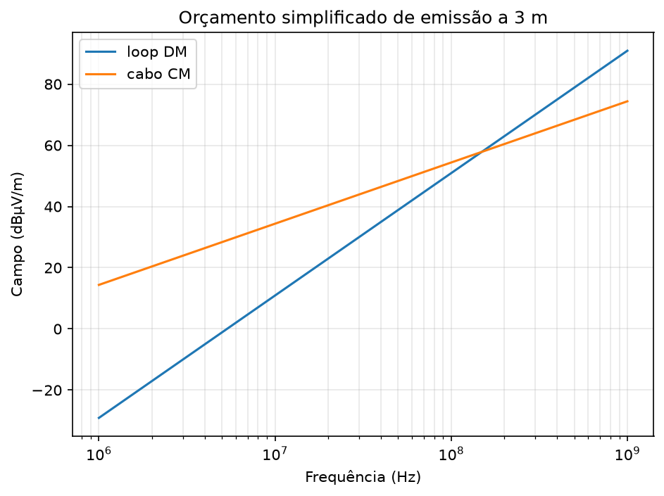

**Limites:** ambos os modelos exigem fontes eletricamente curtas, campo distante, corrente conhecida e máximo angular. Cabos ressonantes, plano de terra e ambiente de ensaio exigem modelo ou medição mais completos.

## 11.20 Suscetibilidade por altura efetiva

Para uma antena receptora linear,

$$ V_{oc}=\vec E\cdot\vec h_{eff},\qquad V_L=V_{oc}\frac{Z_L}{Z_A+Z_L}. $$

### 11.20.1 Exemplo resolvido

Um campo de $10\,\text{V/m}$ incide alinhado a um cabo com $h_{eff}=0{,}12\,\text{m}$. Se $Z_A=150\,\Omega$ e $Z_L=50\,\Omega$, então $V_{oc}=1{,}2\,\text{V}$ e $V_L=0{,}30\,\text{V}$. O cálculo identifica o nível na porta; a falha ainda depende do filtro, da conversão de modo e do limiar funcional.

## 11.21 Reflexão no solo: modelo de dois raios

Em campo aberto, a antena recebe a soma fasorial do caminho direto e do refletido:

$$ E=E_0\left(\frac{e^{-j\beta r_1}}{r_1}+\Gamma\frac{e^{-j\beta r_2}}{r_2}\right). $$

Esse modelo explica máximos e mínimos com altura e frequência. Em ensaio, a varredura de altura busca o máximo, não uma distância que obedeça apenas a $1/r$.

## 11.22 Referência principal

Síntese do Capítulo 8, "Radiated Emissions and Susceptibility", de C. R. Paul, *Introduction to Electromagnetic Compatibility*, 2ª ed., Wiley, 2006, pp. 503–556.